# Calculus Workshop

Algebra and Graphing Problem Set

Nathan Grimes

2023-09-19

*Answer the following questions to the best of your ability. Feel free to work with anyone in the cohort, though I would encourage attempting on your own first to make sure you fully understand the concepts.*

# Algebra basics

1. Describe how solving for the roots (f(x)=0) of equations could be useful in environmental science? List at least one method to do so.
2. Solve for x
   1. $2x-4=3x+12$
   2. $-6ax+2b=x-5c$
3. Solve for x
   1. $2x^2+3x-4=0$
   2. $x^2-2x-5=0$
4. Expand these equations
   1. $(x+2)(3x-4)$
   2. $(x^2-2y)(x+y^3)$

# Story Problems

5. A new RCP 4.5 projections indicates that carbon emissions in the atmosphere will plateau at around 600 ppm. Today’s atmospheric carbon concentration sits at 416 ppm.
   1. If the United States continues to emit proportionally the same amount of carbon (14%), how much carbon will the US emit in 2100 under RCP 4.5? Use the conversion 1ppm=2.13 gigatons.
   2. Let’s say the US decides to pursue an ambitious policy to extract their contribution of carbon from the air. Climatologists model that policy would have a trajectory of $f(c)=\frac{-1}{8}t^2+6t+123.83$ where t is each year and c is the amount of carbon released by the US. When will the United States eliminate their carbon footprint?

# Graphs

6. Find the slope and y-intercept of these graphs

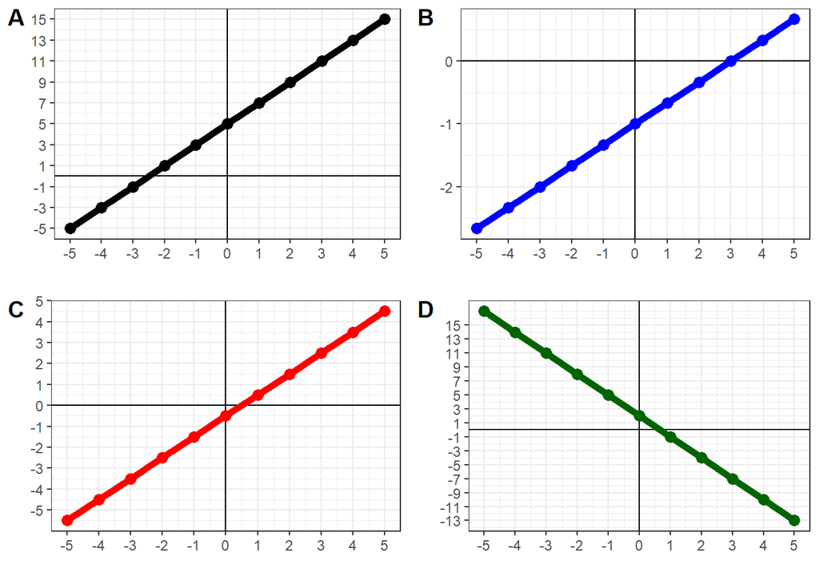

```r
x=seq(-5,5)

y=2*x+5

w=(1/3)*x-1

z=x-0.5

u=-3*x+2

p1<-ggplot()+
  geom_hline(yintercept=0)+
  geom_vline(xintercept = 0)+
  geom_point(aes(x=x,y=y),size=3,color="black")+
  geom_line(aes(x=x,y=y),size=2,color="black")+
  theme_bw()+
  theme(axis.line = element_blank())+
  scale_y_continuous(breaks=seq(-5,15,2))+
  scale_x_continuous(breaks=seq(-5,5,by=1))+
  labs(x="",y="")

p2<-ggplot()+
  geom_hline(yintercept=0)+
  geom_vline(xintercept = 0)+
  geom_point(aes(x=x,y=w),size=3,color="blue")+
  geom_line(aes(x=x,y=w),size=2,color="blue")+
  theme_bw()+
  theme(axis.line = element_blank())+
  scale_y_continuous(breaks=seq(-3,3,1))+
  scale_x_continuous(breaks=seq(-5,5,by=1))+
  labs(x="",y="")

p3<-ggplot()+
  geom_hline(yintercept=0)+
  geom_vline(xintercept = 0)+
  geom_point(aes(x=x,y=z),size=3,color="red")+
  geom_line(aes(x=x,y=z),size=2,color="red")+
  theme_bw()+
  theme(axis.line = element_blank())+
  scale_y_continuous(breaks=seq(-5,5,1))+
  scale_x_continuous(breaks=seq(-5,5,by=1))+
  labs(x="",y="")

p4<-ggplot()+
  geom_hline(yintercept=0)+
  geom_vline(xintercept = 0)+
  geom_point(aes(x=x,y=u),size=3,color="darkgreen")+
  geom_line(aes(x=x,y=u),size=2,color="darkgreen")+
  theme_bw()+
  theme(axis.line = element_blank())+
  scale_y_continuous(breaks=seq(-15,15,2))+
  scale_x_continuous(breaks=seq(-5,5,by=1))+
  labs(x="",y="")

cowplot::plot_grid(p1,p2,p3,p4,labels=c("A","B","C","D"))
```

7. The growth of sharks are modeled from Von Bertalanffy curves. Scalloped hammerhead sharks in the Atlantic were found to have growth curves that follow the chart below.

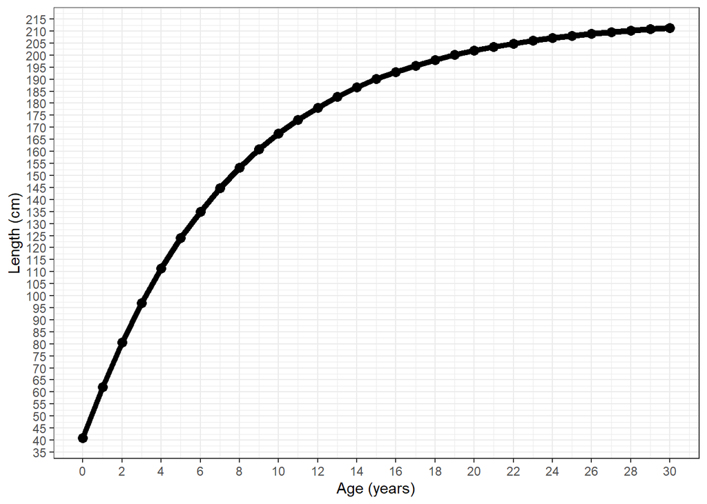

```r
vb<-function(a,l,k,t0){
  l*(1-exp(-k*(a-t0)))
}

x=seq(0,30)

length=vb(x,214.8,.13,-1.62)

p1<-ggplot()+
  geom_point(aes(x=x,y=length),color="black",size=3)+
  geom_line(aes(x=x,y=length),color="black",size=2)+
  theme_bw()+
  scale_y_continuous(breaks=seq(35,215,5))+
  scale_x_continuous(breaks=seq(0,32,by=2))+
  labs(x="Age (years)",y="Length (cm)")

p1
```

1. What is the average slope from ages 0 to 8? From 20 to 30?
2. What are the units of the average slopes and why would they change for a shark as they get older?
3. How would you find the instantaneous slope for a shark at age 12? What is the closest approximation you can make with this data and graph?

[Picture of Scalloped Hammerhead shark](https://inaturalist-open-data.s3.amazonaws.com/photos/19051739/large.jpg)